# COVID19 Data Near Grace College

Compiled by Dr. Ryan Johnson using data from (Guidotti and Ardia 2020)

Last updated 2020-05-08

# Data from Indiana and Neighboring States

### Confirmed Deaths from COVID19

Deaths data are the best indicator of the real prevalence of the disease, but deaths data lags behind case data.

All numbers in this graph are per ten thousand. Dots are the number of new deaths recorded each day. Dashed lines are a weighted average.

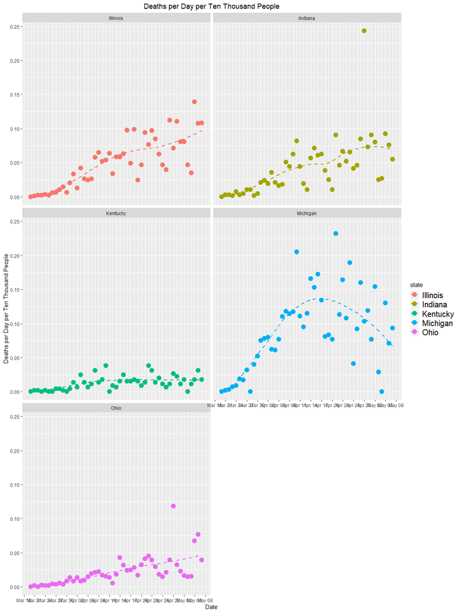

### Confirmed Cases of COVID19

The case data below is also per ten thousand. Dots are new confirmed cases of COVID19 each day. The dashed lines are weighted averages.

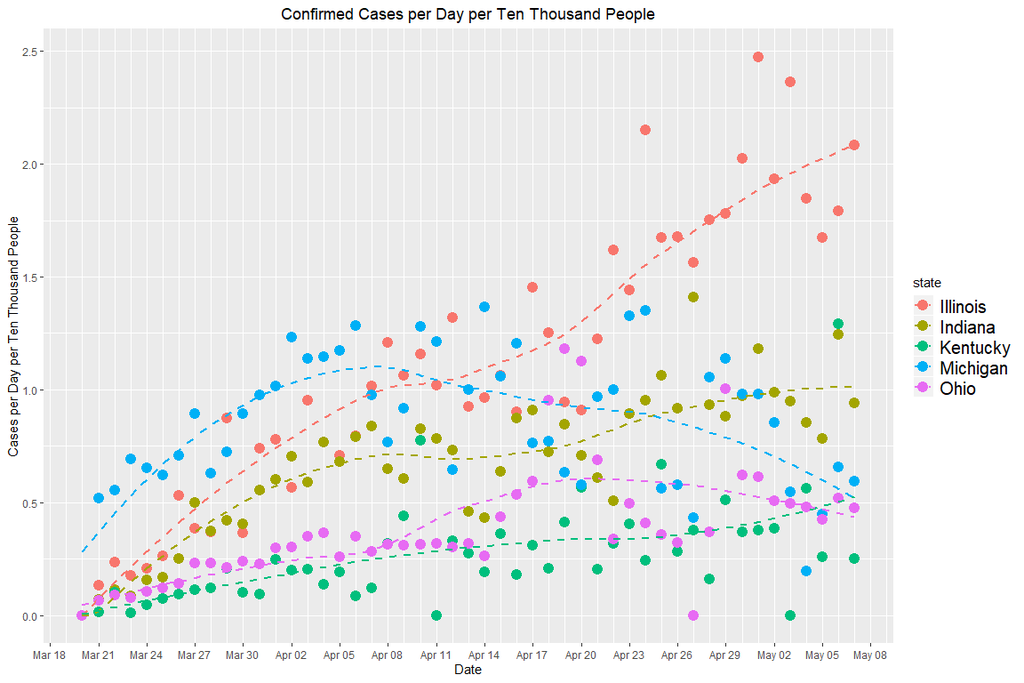

### Positive Test Rate

Looking at the percentage of tests that come back positive can signal which states might have low case numbers because of lack of testing.

For example, Michigan had a much higher death rate per capita than Illinois in mid-April, even though their case numbers per capita were only a little higher in late March and early April. Michigan’s high postive test rate late March and early April suggests that Michigan had worse testing than Illinois during that time.

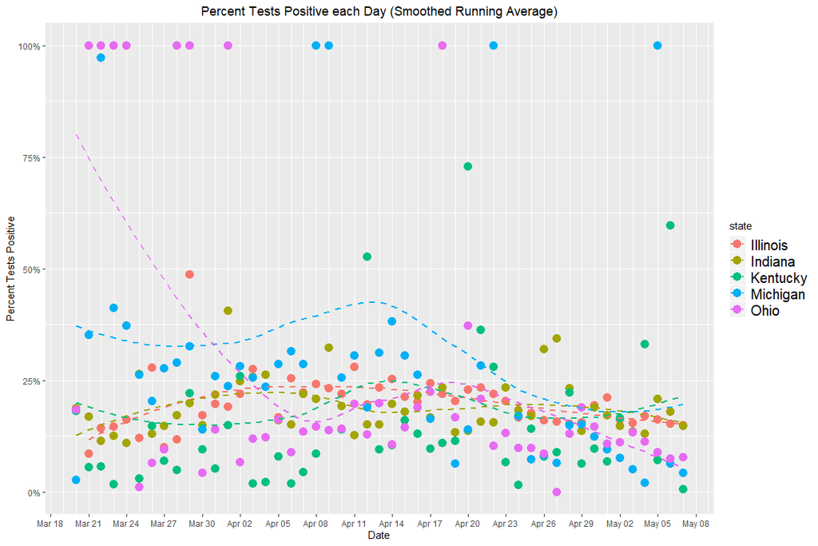

# County Level Data

### Nearest Outbreak

The nearest outbreak is in Cass County, Indiana. It appears to be linked to the Tyson meatpacking plant.

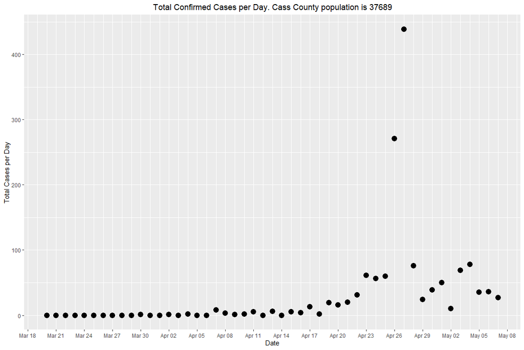

### Non-outbreak Neighbors

Besides Cass County, our neighboring counties have case levels that can fit in roughly the same scale. Notice that the cases below are reported per ten thousand people.

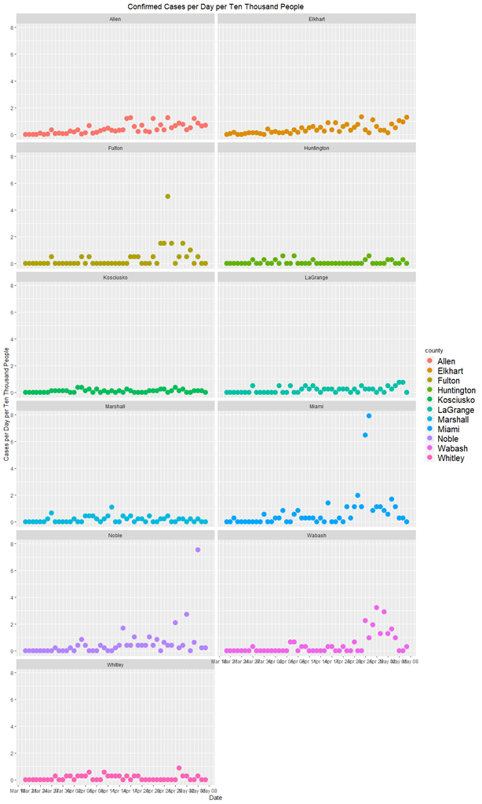

Guidotti, Emanuele, and David Ardia. 2020. “COVID-19 Data Hub.” https://doi.org/10.13140/RG.2.2.11649.81763.